# National and Subnational estimates for Vietnam

Subnational estimates Asia Vietnam

Identifying changes in the reproduction number, rate of spread, and doubling time during the course of the COVID-19 outbreak whilst accounting for potential biases due to delays in case reporting both nationally and subnationally in Vietnam. These results are impacted by changes in testing effort, increases and decreases in testing effort will increase and decrease reproduction number estimates respectively.

*Note that it takes time for infection to cause symptoms, to get tested for SARS-CoV-2 infection, for a positive test to return and ultimately to enter the case data presented here. In other words, today’s case data are only informative of new infections about two weeks ago. This is reflected in the plots below, which are by date of infection.*

*Estimates are available to download [here](https://dataverse.harvard.edu/dataverse/covid-rt).*

*See our see [Methods](https://epiforecasts.io/covid/methods) or our [paper](https://wellcomeopenresearch.org/articles/5-112/) for an explanation of how these estimates are derived.*

*Using data available up to the:* 2022-04-18

*Subnational and national estimates are available to download [here](https://dataverse.harvard.edu/dataverse/covid-rt).*

*See our see [Methods](https://epiforecasts.io/covid/methods) or our [paper](https://wellcomeopenresearch.org/articles/5-112/) for an explanation of how these estimates are derived.*

## National summary

### Summary (estimates as of the 2022-04-18)

*Table 1: Latest estimates (as of the 2022-04-18) of the number of confirmed cases by date of infection, the expected change in daily confirmed cases, the effective reproduction number, the growth rate, and the doubling time (when negative this corresponds to the halving time). The median and 90% credible interval is shown for each numeric estimate.*

|  | Estimate |
| --- | --- |
| New confirmed cases by infection date | 83455 (44264 – 163684) |
| Expected change in daily cases | Likely decreasing |
| Effective reproduction no. | 0.75 (0.55 – 1) |
| Rate of growth | -0.073 (-0.13 – 0.0055) |
| Doubling/halving time (days) | -9.5 (130 – -5.2) |

### Confirmed cases, their estimated date of report, date of infection, and time-varying reproduction number estimates

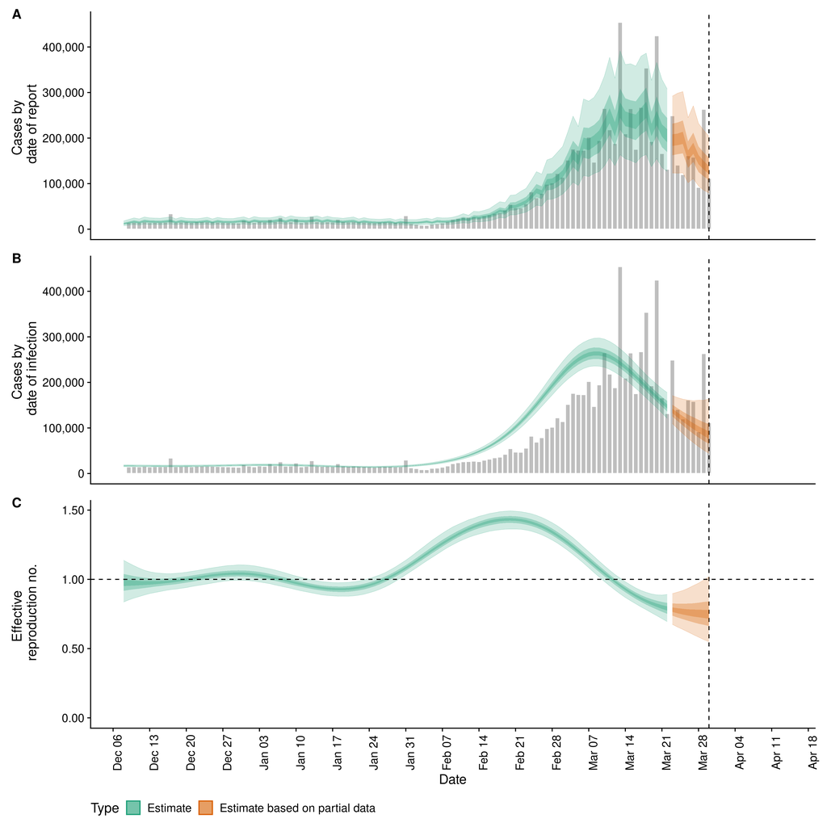

## Subnational breakdown

[interactive chart not shown]

*Figure 2: The results of the latest reproduction number estimates (based on confirmed cases in Vietnam, stratified by Region, can be summarised by whether confirmed cases are likely increasing or decreasing. This represents the strength of the evidence that the reproduction number in each region is greater than or less than 1, respectively (see the [methods](https://epiforecasts.io/covid/methods.html) for details).*

| Region | New confirmed cases by infection date | Expected change in daily cases | Effective reproduction no. | Rate of growth | Doubling/halving time (days) | New confirmed cases by infection date | Effective reproduction no. | Rate of growth | Doubling/halving time (days) |
| --- | --- | --- | --- | --- | --- | --- | --- | --- | --- |
| Angiang | 6 (0 -- 30) | Decreasing | 0.49 (0.21 -- 0.92) | -0.15 (-0.26 -- -0.022) | -4.5 (-32 -- -2.7) | 6 | 0.49 | -0.15 | -4.5 |
| Bacgiang | 101 (9 -- 557) | Decreasing | 0.43 (0.15 -- 0.78) | -0.17 (-0.28 -- -0.062) | -4 (-11 -- -2.4) | 101 | 0.43 | -0.17 | -4 |
| Backan | 171 (22 -- 1092) | Likely decreasing | 0.62 (0.3 -- 1.1) | -0.11 (-0.22 -- 0.026) | -6.3 (27 -- -3.1) | 171 | 0.62 | -0.11 | -6.3 |
| Baclieu | 2 (0 -- 9) | Decreasing | 0.43 (0.18 -- 0.77) | -0.18 (-0.27 -- -0.067) | -3.9 (-10 -- -2.6) | 2 | 0.43 | -0.18 | -3.9 |
| Bacninh | 13 (0 -- 252) | Likely decreasing | 0.44 (0.1 -- 1.3) | -0.17 (-0.31 -- 0.069) | -4 (10 -- -2.2) | 13 | 0.44 | -0.17 | -4 |
| Bariavungtau | 29 (1 -- 370) | Decreasing | 0.39 (0.083 -- 0.89) | -0.19 (-0.32 -- -0.03) | -3.7 (-23 -- -2.2) | 29 | 0.39 | -0.19 | -3.7 |
| Bentre | 0 (0 -- 24) | Decreasing | 0.23 (0.027 -- 0.87) | -0.25 (-0.36 -- -0.036) | -2.8 (-20 -- -1.9) | 0 | 0.23 | -0.25 | -2.8 |
| Binhdinh | 5 (0 -- 36) | Decreasing | 0.33 (0.11 -- 0.68) | -0.21 (-0.31 -- -0.094) | -3.3 (-7.4 -- -2.3) | 5 | 0.33 | -0.21 | -3.3 |
| Binhduong | 1 (0 -- 22) | Decreasing | 0.28 (0.052 -- 0.85) | -0.23 (-0.34 -- -0.041) | -3 (-17 -- -2.1) | 1 | 0.28 | -0.23 | -3 |
| Binhphuoc | 21 (1 -- 170) | Likely decreasing | 0.52 (0.19 -- 1.1) | -0.14 (-0.27 -- 0.032) | -4.8 (22 -- -2.6) | 21 | 0.52 | -0.14 | -4.8 |

[output cut: 54 more lines]

*Table 2: Latest estimates (as of the 2022-04-18) of the number of confirmed cases by date of infection, the effective reproduction number, the rate of growth, and the doubling time (when negative this corresponds to the halving time) in each region. The median and 90% credible interval is shown.*

### Limitations

- Line-list data to inform a region specific estimate of the reporting delay were not available.

Abbott, Sam, Katharine Sherratt, Jonnie Bevan, Hamish Gibbs, Joel Hellewell, James Munday, Patrick Barks, Paul Campbell, Flavio Finger, and Sebastian Funk. 2020. “Covidregionaldata: Subnational Data for the Covid-19 Outbreak.” *-* - (-): –. https://doi.org/10.5281/zenodo.3957539.

“Tabelle Mit Den Aktuellen Covid-19 Infektionen Pro Tag (Zeitreihe).” 2020. Germany: Robert Koch Institut; Bundesamt für Kartographie und Geodäsie. https://npgeo-corona-npgeo-de.hub.arcgis.com/datasets/dd4580c810204019a7b8eb3e0b329dd6_0.

Xu, Bo, Bernardo Gutierrez, Sarah Hill, Samuel Scarpino, Alyssa Loskill, Jessie Wu, Kara Sewalk, et al. n.d. “Epidemiological Data from the nCoV-2019 Outbreak: Early Descriptions from Publicly Available Data.” http://virological.org/t/epidemiological-data-from-the-ncov-2019-outbreak-early-descriptions-from-publicly-available-data/337.

Share: